# Coursework Report for 218222

*N* removed NAs: 2

*N* removed typo: 1

*N* removed <18: 42

*N* total clean: 106

| Group | *N* | *M*<sub>age</sub> | *M*<sub>rating</sub> |
| --- | --- | --- | --- |
| Control | 59 | 20.9 | 5.06 |
| Experim | 47 | 21.0 | 6.52 |

**Main analysis results**

*t*(104) = -10.31, *p* < .001

[interactive chart not shown]

[figure not shown]

[interactive chart not shown]

# Coursework Report for 218222

Analysing Data, Spring 2020

# Methods

## Participants

Table of Descriptive Statistics for Conditions

| Condition | N | % | *Mean* Age | *SD* Age |
| --- | --- | --- | --- | --- |
| control | 59 | 55.7 | 20.9 | 2.30 |
| experimental | 47 | 44.3 | 21.0 | 2.31 |

## Design

**Independant Variables** - categorical/factor

- **Condition** is the type of experiment that the participant underwent.
  - *Control* means they were presented with an image on a white background.
  - *Experimental* means they were presented with an image on a red background.

**Dependant Variables** - continuous

- The **Question_1/2/3** variables determines their answer to the question on a 9-point scale (1 being not attractive and 9 being highly attractive).
  - *Question 1* rates the attractiveness of the image.
  - *Question 2* rates the pleasantness of the image.
  - *Question 3* rates the percieved attractiveness if participants were to meet the person in real life.

We will be doing a t-test to correlate the composite scores provided with the colour groups (condition) to determine whether there is a correlation between attractiveness and, in this case, the colour red.

# Results

It can be observed in *Figure 1 and 2* that those in the experimental group tended to rate higher than those in the control group.

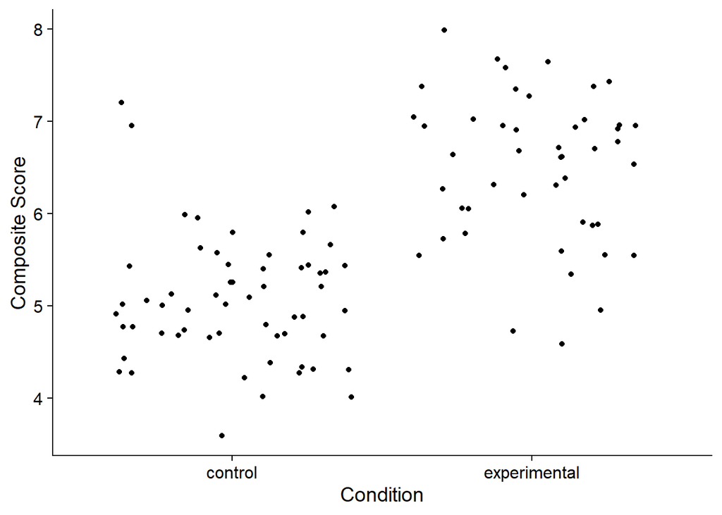

*Figure 1*

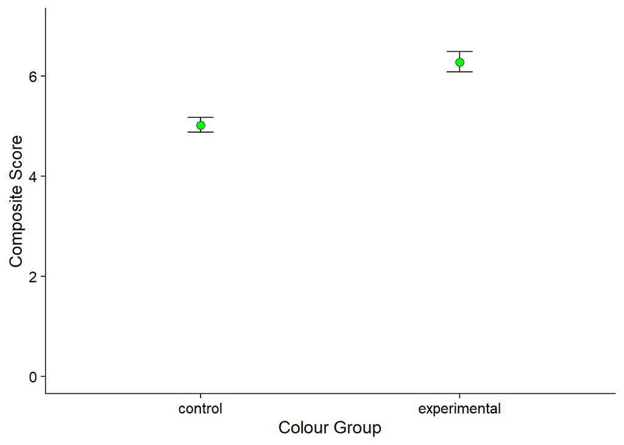

*Figure 2*

The **t-test** is measuring the ‘size of difference in relation to the error’.

- *Null hypothesis*: There is no relationship between the colour red and attractiveness.
- *Alternate hypothesis*: There is a relationship between the colour red and attractiveness.

The t-test results determine that there is a p-value of: 0. This value is lower than 5% significance which reveals that there is a statistical difference between the means of the two groups.

# Discussion

When applied to real life, this experiment could prove to be a foundation for future tests on the relationship between colour and attractiveness. This could be used as a stepping stone for understanding colour psychology and the way that other colours influence people. There are many opposing studies which believe that there is no relationship so, perhaps this study can offer a further input to those that believe different to what this data suggests.

This test has many limitations:

- Most notably, there are only three questions with data for our dependant variables which means a less accurate result. In all aspects of testing, the larger quantity of results the better.
- Furthermore, due to the auto-generation factor in recieving these results, it is possible that these results do not reflect the same as they would with human participants.
- It also does not take into account the person’s sexuality as those that are not attracted to gender of the person in the presented image could disrupt the results due to their attraction ratings.
- All the data presented is given in quantitative data form which, while aids in measuring statistics, cannot help us understand the emotional effect discrepancies between colour groups. Perhaps including a qualitative data input could allow for further exploration into the topic.
- The data was reasonably reliable but contained unethical sources such as minors and unreliable data inputs like the N/A ages and the typos which cause the entire participants’ answers to become redunant. This can be solved by giving parameters when collecting data (such as if it was conducted on an online survey, use a drop-down menu for age rather than a character box.)

It also had strengths such as generally a large pool of participants (106 usable sources) and mostly reliable data. Assuming the data was primary data, taking it directly from the source is much more reliable than secondary data. However, as this is a simulated dataset it cannot truly be known how reliable the data is.

This study has provided information on the topic of colour psychology. It helps to narrow our psychological understanding and aid in understanding how colour affects and influences those around us. Perhaps what we can take away from this study is that there are many simple things such as colour that can change our minds and make us see things in a different light.

# References

Elliot, A., & Maier, M. (2013). The red-attractiveness effect, applying the Ioannidis and Trikalinos (2007b) test, and the broader scientific context: A reply to Francis (2013). Journal Of Experimental Psychology: General, 142(1), 297-300. https://doi.org/10.1037/a0029592

Elliot, A., Niesta Kayser, D., Greitemeyer, T., Lichtenfeld, S., Gramzow, R., Maier, M., & Liu, H. (2010). Red, rank, and romance in women viewing men. Journal Of Experimental Psychology: General, 139(3), 399-417. https://doi.org/10.1037/a0019689

Hesslinger, V., Goldbach, L., & Carbon, C. (2015). Men in red: A reexamination of the red-attractiveness effect. Psychonomic Bulletin & Review, 22(4), 1142-1148. https://doi.org/10.3758/s13423-015-0866-8

Peperkoorn, L., Roberts, S., & Pollet, T. (2016). Revisiting the Red Effect on Attractiveness and Sexual Receptivity. Evolutionary Psychology, 14(4), 147470491667384. https://doi.org/10.1177/1474704916673841